```python
import numpy as np
import matplotlib.pyplot as plt
import pint
SI = pint.UnitRegistry()
```

# Teoría de sepación por gravedad

La remoción por gravedad de material suspendido y coloidal del agua residual es una de las operaciones unitarias más usadas.

Se usa para remover:

- arenas
- SST en sedimentadores primarios
- floculos biológicos o químicos en taques de sedimentación

con el objetivo de producir un efluete clarificado. También se usa para concentrar lodos y puedan ser fácilmente manejables y tratables.

Existen cuatro tipos de sedimentación por gravedad:

1. partículas discretas
2. floculenta
3. zonal o de caida interferida
4. por compresión

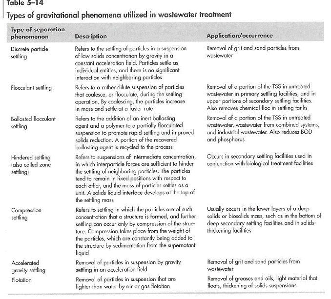

## Sedimentación de partículas discretas

$$v_{p(t)}=\sqrt{\frac{4g}{3C_d}\left(\frac{\rho_p-\rho_w}{\rho_w} \right)}\approx \sqrt{\frac{4g}{3C_d}(sg_p-1)d_p}$$

donde:

- $v_{p(t)}=$ velocidad terminal de la partícula,$m\,s^{-1}$
- $d_p=$ diámetro de la partícula, $m$
- $sg_p=$ gravedad específica de la partícula
- $C_d=$ coeficiente de arrastre,$[-]$

El coeficiente $C_d$ depende del régimen hidrodinámico (laminar o turbulento) que rodea a la partícula y de la forma de la partícula:

- laminar si $Re<1$
- transición si $1<Re<2000$
- turbulento si $Re>2000$

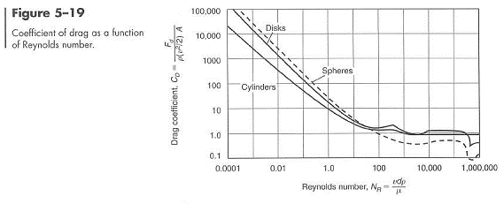

$$Re=\frac{v_p\,d_p\,\rho_w}{\mu}=\frac{v_p\,d_p}{\nu}$$

donde:

- $\mu=$ viscosidad dinámica, $N\,s\,m^{-2}$
- $\nu=$ viscosidad cinemática, $m^2\,s^{-1}$

Para partículas que son aproximadamente esféricas, el $C_d$ se puede aproximar por la siguiente ecuación:

$$C_d=\frac{24}{Re}+\frac{3}{\sqrt{Re}}+0.34 $$

Para partículas que no son esféricas:

$$v_{p(t)}=\sqrt{\frac{4g}{3C_d\phi}(sg_p-1)d_p} $$

donde:

- $\phi$ es un factor de forma
  > - $\phi=1.0$ para esferas
  > - $\phi=2.0$ para granos de arena
  > - $\phi>0$ para floculos

### Sedimentación en la región laminar, $Re<1$

En estas condiciones, las fuerzas viscosas son las que dominan el proceso de sedimentación, por lo tanto:

$$C_d=\frac{24}{Re}$$

Asumiendo partículas esféricas $(\phi=1)$, se tiene que:

$$v_{p(t)}=\frac{g(\rho_p-\rho_w)d_{p}^{2}}{18\,\mu}\approx \frac{g(sg_p-1)d_{p}^{2}}{18\,\nu}$$

### Sedimentación en la región de transición

En esta región se debe utilizar la forma completa del $C_d$

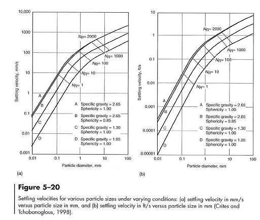

### Sedimentación en la región turbulenta

En estas condiciones, las fuerzas inerciales predominan, por lo tanto, los dos primeros térmimos de la ecuación para el $C_d$ son pequeños, se usa un valor de $0.4$ para el coeficiente de arrastre:

$$v_{p(t)}=\sqrt{3.33\,g\left(\frac{\rho_p-\rho_w}{\rho_w} \right)}\approx \sqrt{3.33\,g(sg_p-1)d_p} $$

#### Ejemplo 5-5 Determine la velocidad terminal de sedimentación

- arena con un diámetro promedio de $0.5\,mm$
- factor de forma de $0.85$
- temperatura del agua de $20^{o}C$
- gravedad específica de 2.65,$[-]$
- viscosidad cinemática $\nu(20^o\,C)=1.003\times 10^{-6}\, m^2\,s^{-1}$

```python
dp=(0.5/1000)*SI.meter
phi=0.85
T_agua=20
sg_p=2.65
nu=1.003e-6*(SI.meter**2/SI.second)
g=9.81*(SI.meter/SI.second**2)
```

#### Paso 1

Determinar la velocidad terminal de sedimentación utilizando la ley de Stoke

```python
vp = g*(sg_p-1)*dp**2/(18*nu)
print(vp)
```

```
0.224140079761 meter / second
```

#### Paso 2

Verificar el número de Reynolds

```python
Re=phi*vp*dp/nu
print(Re)
```

```
94.9746100681 dimensionless
```

Como $Re > 1$ la ley de Stokes no es valida en este régimen, por lo tanto se debe usar la ley de Newton.

```python
MAXIT=20
EPSILON=0.00001
for i in range(MAXIT):
    CD=(24/Re)+(3/np.sqrt(Re))+0.34
    vp_n = np.sqrt(4*g*(sg_p-1)*dp/(3*CD))
    ERROR=np.fabs(vp_n-vp)
    if ERROR<= EPSILON:
        print(vp_n)
        break
    else:
        Re=phi*vp*dp/nu
        vp=vp_n
```

```
0.109466402778 meter / second
```